# Your Data Deserves Better: Understanding When to Use EFA or PCA

If you’ve ever opened SPSS -> Dimensionality Reduction -> Factor and wondered whether to choose EFA or PCA you’re not alone. These two methods sit side-by-side, look almost identical, and are often mixed up—even in published research. But they serve very different purposes, especially when we’re trying to understand psychological constructs. In this post, I’ll walk you through what those differences are and why they matter.

Psychometrics

Statistics

Author

Affiliation

[Md Allama Ikbal Sijan](https://sijan14.github.io/sijan_portfolio)

Doctorate of Industrial-Organizational Psychology (Data Science) @ Montclair State University

Published

April 14, 2025

## 🌟 Introduction

Factor analysis is one of the most important tools psychometricians use to understand latent constructs. Before we jump into the analysis itself, let’s take a step back and talk about what a latent construct even is (in case you are not familliar). A construct is a theoretical, abstract idea that we can’t directly measure. Most psychological things fall under this category—our emotions, thoughts, internal processes, motivations, attitudes… none of this is directly visible. That’s why we call them latent constructs (latent = hidden).

Even though we can’t observe a construct directly, we can infer it through things we can observe—like self-reported behaviors, responses to questionnaire items, performance on tasks, physiological signals, and so on.

## 🔎 A Quick Example

Think about intelligence testing. “Intelligence” is not something we can see or touch. But we can observe things like quantitative reasoning, verbal reasoning, and problem-solving speed. By measuring those observable skills, we infer something about the latent construct of intelligence.

Now, yes—there’s a huge debate about what intelligence even is, whether it’s innate, how much it can change, and whether practice effects undermine certain definitions. That’s a conversation for another day. The point is: psychometric tests let us learn about latent factors through observable variables that are easy to measure. And once we measure them, we can evaluate reliability, validity, and use them to predict or understand all sorts of fun things in academic and applied settings.

## 🌝 EFA vs. CFA: what’s the difference?

There are two types of factor analysis:

#### Confirmatory Factor Analysis (CFA)

CFA is used when you already have a theory or hypothesis. You’re basically asking, “Does my data support the structure I expect?” You test whether the model you believe in can be reproduced using your observed data.

#### Exploratory Factor Analysis (EFA)

EFA is used when you don’t have a strong theory yet. You explore the data to see how many factors best explain the relationships among your observed variables. It’s like asking: “What structure naturally emerges from these items?”

For example, imagine personality research didn’t exist yet. You write a ton of items that describe different behaviors and attitudes. You don’t know how many dimensions of personality there are, or what they are. You run EFA to see which items “hang together,” and maybe you discover several clusters of items. You then interpret and name those clusters—maybe you end up with something like Oppenness, Conscientiousness, Extraversion, Agreeableness, and Neuroticism.

Mathematically, EFA is asking: Can a smaller number of underlying factors explain the variance and correlations we see in these measured variables?

It’s really just statistics doing what it always does: trying to explain variation.

- ANOVA: do different groups explain variance in an outcome?
- Regression: do predictors explain variance in an outcome?
- EFA: do latent factors explain variance in many observed variables? Same logic—different target.

## 🙉 So where does PCA come in, and why is it a problem?

Another technique commonly used in our field is Principal Components Analysis (PCA). It looks very similar to EFA, so similar that software (like SPSS) puts them under the same menu. Unfortunately, this causes a lot of researchers to confuse the two and accidentally use PCA when they meant to use EFA.

And the problem is widespread: In a review of two measurement journals across six years, 64% of papers used PCA, while only 33% used EFA (Osborne et al., 2008). PCA is simply easier to click, so people default to it even when it’s not appropriate. Let’s get clear about the difference.

## The Key Distinction

Both PCA and EFA reduce data, but they do it for very different reasons.

#### EFA: modeling underlying causes

EFA assumes that latent factors cause the observed variables.

The idea is:

```
    Factor → Variables
```

Mathematically:

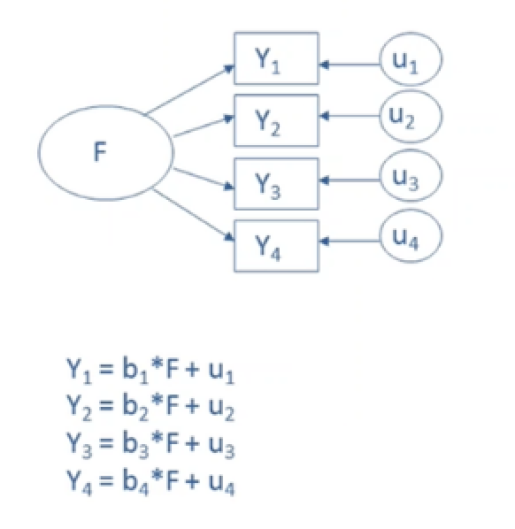

Source: Karen Grace-Martin, TheAnalysisFactor.com

#### PCA: creating weighted combinations

PCA assumes the variables create the components. No underlying psychological cause—just weighted math.

```
    Variables → Component
```

Mathematically:

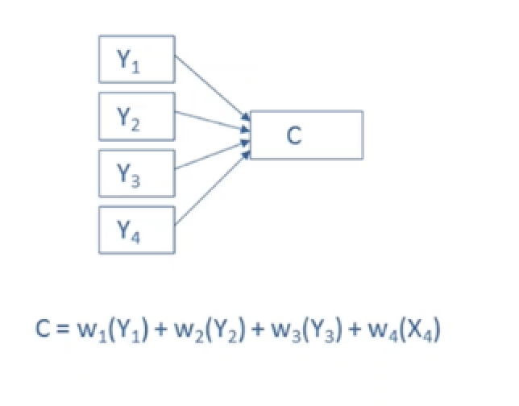

Source: Karen Grace-Martin, TheAnalysisFactor.com

So PCA components are literally linear combinations of the observed variables—not latent constructs.

*Note.* Throughout this blog, I use the terms “item,” “variable,” and “observed variable” interchangeably, as they refer to the same concept.

## 🤔 What makes them fundamentally different: the mathematical assumption

The major difference is how each method treats variance:

#### EFA

- The diagonal of the covariance matrix < 1
- Because variance is split into shared and unique parts
- The diagonal only contains shared variance (communalities)
- Meaning: EFA assumes variables have unique variance and measurement error

#### PCA

- The diagonal is constrained to be 1
- Meaning it assumes each variable’s entire variance is shared with all other variables (aka items)
- No measurement error, no unique variance
- This is almost never true in real data

This is why PCA is not good for theory building. It doesn’t model latent constructs. It doesn’t account for measurement error. It just compresses variables.

## 📜 So when should you use which?

#### Use EFA when

- You want to discover latent constructs
- You care about theory
- You want to model measurement error
- You’re building a scale
- You’re doing psychometric work

(Use Principal Axis Factoring or Maximum Likelihood—not PCA—as your extraction method in SPSS.)

#### Use PCA when

- You purely want to reduce the number of variables
- You don’t care about underlying constructs
- You want to avoid multicollinearity
- You want fewer predictors for machine learning models
- You’re trying to simplify a large dataset

PCA is great for data prep—but not for understanding psychological constructs.

## 🧠 Final Thoughts

EFA and PCA look similar, but they answer completely different questions. When we mix them up, we unintentionally do bad science—not because we want to, but because the software makes it too easy to click the wrong thing.

So let’s be intentional about the tools we use. If you’re trying to understand a psychological construct, stick with EFA. If you’re just trying to shrink a large set of variables for practical reasons, PCA can be your friend.

## 🔗 References

Tabachnick, B. G., & Fidell, L. S. (2018). Using multivariate statistics (7th ed.). Pearson.

user_anon (https://stats.stackexchange.com/users/125475/user-anon), Fundamental difference between PCA and FA?, URL (version: 2018-09-14): https://stats.stackexchange.com/q/366970

## Citation

BibTeX citation:

```
@online{allama ikbal sijan2025,
  author = {Allama Ikbal Sijan, Md},
  title = {Your {Data} {Deserves} {Better:} {Understanding} {When} to
    {Use} {EFA} or {PCA}},
  date = {2025-04-14},
  url = {https://sijan14.github.io/sijan_portfolio/posts/2025-04-14-EFA-PCA/},
  langid = {en}
}
```

For attribution, please cite this work as:

Allama Ikbal Sijan, Md. 2025. “Your Data Deserves Better: Understanding When to Use EFA or PCA.” April 14, 2025. https://sijan14.github.io/sijan_portfolio/posts/2025-04-14-EFA-PCA/.